# **Launch Sites Locations Analysis with Folium**

Estimated time needed: **40** minutes

The launch success rate may depend on many factors such as payload mass, orbit type, and so on. It may also depend on the location and proximities of a launch site, i.e., the initial position of rocket trajectories. Finding an optimal location for building a launch site certainly involves many factors and hopefully we could discover some of the factors by analyzing the existing launch site locations.

In the previous exploratory data analysis labs, you have visualized the SpaceX launch dataset using `matplotlib` and `seaborn` and discovered some preliminary correlations between the launch site and success rates. In this lab, you will be performing more interactive visual analytics using `Folium`.

## Objectives

This lab contains the following tasks:

- **TASK 1:** Mark all launch sites on a map
- **TASK 2:** Mark the success/failed launches for each site on the map
- **TASK 3:** Calculate the distances between a launch site to its proximities

After completed the above tasks, you should be able to find some geographical patterns about launch sites.

Let's first import required Python packages for this lab:

```python
import piplite
await piplite.install(['folium'])
await piplite.install(['pandas'])
```

```python
import folium
import pandas as pd
```

```python
# Import folium MarkerCluster plugin
from folium.plugins import MarkerCluster
# Import folium MousePosition plugin
from folium.plugins import MousePosition
# Import folium DivIcon plugin
from folium.features import DivIcon
```

If you need to refresh your memory about folium, you may download and refer to this previous folium lab:

[Generating Maps with Python](https://cf-courses-data.s3.us.cloud-object-storage.appdomain.cloud/IBM-DS0321EN-SkillsNetwork/labs/module_3/DV0101EN-3-5-1-Generating-Maps-in-Python-py-v2.0.ipynb)

## Task 1: Mark all launch sites on a map

First, let's try to add each site's location on a map using site's latitude and longitude coordinates

The following dataset with the name `spacex_launch_geo.csv` is an augmented dataset with latitude and longitude added for each site.

```python
# Download and read the `spacex_launch_geo.csv`
from js import fetch
import io

URL = 'https://cf-courses-data.s3.us.cloud-object-storage.appdomain.cloud/IBM-DS0321EN-SkillsNetwork/datasets/spacex_launch_geo.csv'
resp = await fetch(URL)
spacex_csv_file = io.BytesIO((await resp.arrayBuffer()).to_py())
spacex_df=pd.read_csv(spacex_csv_file)
```

Now, you can take a look at what are the coordinates for each site.

```python
# Select relevant sub-columns: `Launch Site`, `Lat(Latitude)`, `Long(Longitude)`, `class`
spacex_df = spacex_df[['Launch Site', 'Lat', 'Long', 'class']]
launch_sites_df = spacex_df.groupby(['Launch Site'], as_index=False).first()
launch_sites_df = launch_sites_df[['Launch Site', 'Lat', 'Long']]
launch_sites_df
```

|  | Launch Site | Lat | Long |
| --- | --- | --- | --- |
| 0 | CCAFS LC-40 | 28.562302 | -80.577356 |
| 1 | CCAFS SLC-40 | 28.563197 | -80.576820 |
| 2 | KSC LC-39A | 28.573255 | -80.646895 |
| 3 | VAFB SLC-4E | 34.632834 | -120.610745 |

Above coordinates are just plain numbers that can not give you any intuitive insights about where are those launch sites. If you are very good at geography, you can interpret those numbers directly in your mind. If not, that's fine too. Let's visualize those locations by pinning them on a map.

We first need to create a folium `Map` object, with an initial center location to be NASA Johnson Space Center at Houston, Texas.

```python
# Start location is NASA Johnson Space Center
nasa_coordinate = [29.559684888503615, -95.0830971930759]
site_map = folium.Map(location=nasa_coordinate, zoom_start=10)
```

We could use `folium.Circle` to add a highlighted circle area with a text label on a specific coordinate. For example,

```python
# Create a orange circle at NASA Johnson Space Center's coordinate with a popup label showing its name
circle = folium.Circle(nasa_coordinate, radius=1000, color='#d35400', fill=True).add_child(folium.Popup('NASA Johnson Space Center'))
# Create a orange circle at NASA Johnson Space Center's coordinate with a icon showing its name
marker = folium.map.Marker(
    nasa_coordinate,
    # Create an icon as a text label
    icon=DivIcon(
        icon_size=(20,20),
        icon_anchor=(0,0),
        html='<div style="font-size: 12; color:#d35400;"><b>%s</b></div>' % 'NASA JSC',
        )
    )
site_map.add_child(circle)
site_map.add_child(marker)
```

Make this Notebook Trusted to load map: File -> Trust Notebook

[interactive chart not shown]

Now, let's add a circle for each launch site in data frame `launch_sites`

*TODO:* Create and add `folium.Circle` and `folium.Marker` for each launch site on the site map

An example of folium.Circle:

`folium.Circle(coordinate, radius=1000, color='#000000', fill=True).add_child(folium.Popup(...))`

An example of folium.Marker:

`folium.map.Marker(coordinate, icon=DivIcon(icon_size=(20,20),icon_anchor=(0,0), html='<div style="font-size: 12; color:#d35400;"><b>%s</b></div>' % 'label', ))`

### Transforming the Launch Sites Dataframe to a Dictionary

**Setting the index to 'Launch Site' (Still a Dataframe)**

```python
launch_sites_dict = launch_sites_df.set_index('Launch Site')
launch_sites_dict
```

| Launch Site | Lat | Long |
| --- | --- | --- |
| CCAFS LC-40 | 28.562302 | -80.577356 |
| CCAFS SLC-40 | 28.563197 | -80.576820 |
| KSC LC-39A | 28.573255 | -80.646895 |
| VAFB SLC-4E | 34.632834 | -120.610745 |

**Transposing the dataframe**

```python
launch_sites_dict = launch_sites_dict.T
launch_sites_dict
```

| Launch Site | CCAFS LC-40 | CCAFS SLC-40 | KSC LC-39A | VAFB SLC-4E |
| --- | --- | --- | --- | --- |
| Lat | 28.562302 | 28.563197 | 28.573255 | 34.632834 |
| Long | -80.577356 | -80.576820 | -80.646895 | -120.610745 |

**Transforming from dataframe to Dictionary with the launch sites being the keys.**

```python
launch_sites_dict = launch_sites_dict.to_dict('List')
launch_sites_dict
```

```
{'CCAFS LC-40': [28.56230197, -80.57735648],
 'CCAFS SLC-40': [28.56319718, -80.57682003],
 'KSC LC-39A': [28.57325457, -80.64689529],
 'VAFB SLC-4E': [34.63283416, -120.6107455]}
```

```python
launch_sites_dict['CCAFS SLC-40']
```

```
[28.56319718, -80.57682003]
```

### Marking the Launch Sites in the map

```python
# Initial the map
site_map = folium.Map(location=nasa_coordinate, zoom_start=5)
# For each launch site, add a Circle object based on its coordinate (Lat, Long) values. In addition, add Launch site name as a popup label
CCAFS_LC40_circle = folium.Circle(launch_sites_dict['CCAFS LC-40'],
                                  radius=1000,
                                  color='#2207C5',
                                  fill=True).add_child(folium.Popup('CCAFS LC-40'))

CCAFS_LC40_marker = folium.map.Marker(launch_sites_dict['CCAFS LC-40'],
                                      icon = DivIcon(icon_size = (20,20),
                                                     icon_anchor = (0,0),
                                                     html = '<div style="font-size: 12; color:#0E034D;"><b>%s</b></div>' % 'CCAFS LC-40'))

CCAFS_SLC40_circle = folium.Circle(launch_sites_dict['CCAFS SLC-40'],
                                  radius=1000,
                                  color='#2207C5',
                                  fill=True).add_child(folium.Popup('CCAFS SLC-40'))

CCAFS_SLC40_marker = folium.map.Marker(launch_sites_dict['CCAFS SLC-40'],
                                      icon = DivIcon(icon_size = (20,20),
                                                     icon_anchor = (0,0),
                                                     html = '<div style="font-size: 12; color:#0E034D;"><b>%s</b></div>' % 'CCAFS SLC-40'))

KSC_LC39A_circle = folium.Circle(launch_sites_dict['KSC LC-39A'],
                                  radius=1000,
                                  color='#2207C5',
                                  fill=True).add_child(folium.Popup('KSC LC-39A'))

KSC_LC39A_marker = folium.map.Marker(launch_sites_dict['KSC LC-39A'],
                                      icon = DivIcon(icon_size = (20,20),
                                                     icon_anchor = (0,0),
                                                     html = '<div style="font-size: 12; color:#0E034D;"><b>%s</b></div>' % 'KSC LC-39A'))

VAFB_SLC4E_circle = folium.Circle(launch_sites_dict['VAFB SLC-4E'],
                                  radius=1000,
                                  color='#2207C5',
                                  fill=True).add_child(folium.Popup('VAFB SLC-4E'))

VAFB_SLC4E_marker = folium.map.Marker(launch_sites_dict['VAFB SLC-4E'],
                                      icon = DivIcon(icon_size = (20,20),
                                                     icon_anchor = (0,0),
                                                     html = '<div style="font-size: 12; color:#0E034D;"><b>%s</b></div>' % 'VAFB SLC-4E'))

site_map.add_child(CCAFS_LC40_circle)
site_map.add_child(CCAFS_SLC40_circle)
site_map.add_child(KSC_LC39A_circle)
site_map.add_child(VAFB_SLC4E_circle)
site_map.add_child(CCAFS_LC40_marker)
site_map.add_child(CCAFS_SLC40_marker)
site_map.add_child(KSC_LC39A_marker)
site_map.add_child(VAFB_SLC4E_marker)
```

Make this Notebook Trusted to load map: File -> Trust Notebook

[interactive chart not shown]

**Reducing the code with for loop**

```python
# Initial the map
site_map_alt = folium.Map(location=nasa_coordinate, zoom_start=5)
Circles = folium.map.FeatureGroup()
Markers = folium.map.FeatureGroup()
# For each launch site, add a Circle object based on its coordinate (Lat, Long) values. In addition, add Launch site name as a popup label
for site, lat, lng in zip(launch_sites_df['Launch Site'], launch_sites_df['Lat'], launch_sites_df['Long']):
    Circles.add_child(folium.Circle([lat, lng],
                                    radius=50,
                                    color='#C606B8',
                                    fill=True).add_child(folium.Popup(site))
                     )

for site, lat, lng in zip(launch_sites_df['Launch Site'], launch_sites_df['Lat'], launch_sites_df['Long']):
    Markers.add_child(folium.map.Marker([lat, lng],
                                        icon = DivIcon(icon_size = (20,20),
                                                       icon_anchor = (0,0),
                                                       html = '<div style="font-size: 12; color:#61035A;"><b>%s</b></div>' % site))
                     )

site_map_alt.add_child(Circles)
site_map_alt.add_child(Markers)
```

Make this Notebook Trusted to load map: File -> Trust Notebook

[interactive chart not shown]

The generated map with marked launch sites should look similar to the following:

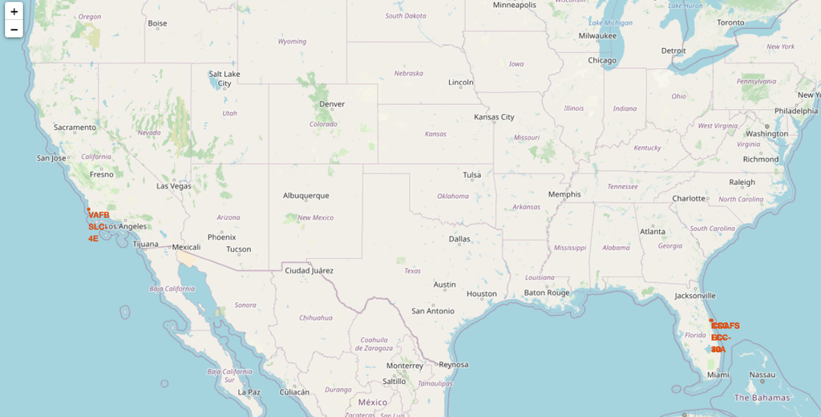

[figure not shown]

Now, you can explore the map by zoom-in/out the marked areas , and try to answer the following questions:

- Are all launch sites in proximity to the Equator line?
- Are all launch sites in very close proximity to the coast?

Also please try to explain your findings.

## Task 2: Mark the success/failed launches for each site on the map

Next, let's try to enhance the map by adding the launch outcomes for each site, and see which sites have high success rates. Recall that data frame spacex_df has detailed launch records, and the `class` column indicates if this launch was successful or not

```python
spacex_df.tail(10)
```

[output not shown]

Next, let's create markers for all launch records. If a launch was successful `(class=1)`, then we use a green marker and if a launch was failed, we use a red marker `(class=0)`

Note that a launch only happens in one of the four launch sites, which means many launch records will have the exact same coordinate. Marker clusters can be a good way to simplify a map containing many markers having the same coordinate.

Let's first create a `MarkerCluster` object

```python
marker_cluster = MarkerCluster()
```

*TODO:* Create a new column in `launch_sites` dataframe called `marker_color` to store the marker colors based on the `class` value

```python
# Apply a function to check the value of `class` column
# If class=1, marker_color value will be green
# If class=0, marker_color value will be red

launch_sites = spacex_df
marker_color = []
launch_status = []

for i in launch_sites['class']:
    success = i
    if success==1:
        color='green'
        status='Success'
        marker_color.append(color)
        launch_status.append(status)
    else:
        color='red'
        status='Failed'
        marker_color.append(color)
        launch_status.append(status)

launch_sites['marker_color'] = marker_color
launch_sites['status'] = launch_status
launch_sites
```

|  | Launch Site | Lat | Long | class | marker_color | status |
| --- | --- | --- | --- | --- | --- | --- |
| 0 | CCAFS LC-40 | 28.562302 | -80.577356 | 0 | red | Failed |
| 1 | CCAFS LC-40 | 28.562302 | -80.577356 | 0 | red | Failed |
| 2 | CCAFS LC-40 | 28.562302 | -80.577356 | 0 | red | Failed |
| 3 | CCAFS LC-40 | 28.562302 | -80.577356 | 0 | red | Failed |
| 4 | CCAFS LC-40 | 28.562302 | -80.577356 | 0 | red | Failed |
| 5 | CCAFS LC-40 | 28.562302 | -80.577356 | 0 | red | Failed |
| 6 | CCAFS LC-40 | 28.562302 | -80.577356 | 0 | red | Failed |
| 7 | CCAFS LC-40 | 28.562302 | -80.577356 | 0 | red | Failed |
| 8 | CCAFS LC-40 | 28.562302 | -80.577356 | 0 | red | Failed |
| 9 | CCAFS LC-40 | 28.562302 | -80.577356 | 0 | red | Failed |
| 10 | CCAFS LC-40 | 28.562302 | -80.577356 | 0 | red | Failed |
| 11 | CCAFS LC-40 | 28.562302 | -80.577356 | 0 | red | Failed |
| 12 | CCAFS LC-40 | 28.562302 | -80.577356 | 0 | red | Failed |
| 13 | CCAFS LC-40 | 28.562302 | -80.577356 | 0 | red | Failed |
| 14 | CCAFS LC-40 | 28.562302 | -80.577356 | 0 | red | Failed |
| 15 | CCAFS LC-40 | 28.562302 | -80.577356 | 0 | red | Failed |
| 16 | CCAFS LC-40 | 28.562302 | -80.577356 | 0 | red | Failed |
| 17 | CCAFS LC-40 | 28.562302 | -80.577356 | 1 | green | Success |
| 18 | CCAFS LC-40 | 28.562302 | -80.577356 | 1 | green | Success |
| 19 | CCAFS LC-40 | 28.562302 | -80.577356 | 0 | red | Failed |
| 20 | CCAFS LC-40 | 28.562302 | -80.577356 | 1 | green | Success |
| 21 | CCAFS LC-40 | 28.562302 | -80.577356 | 1 | green | Success |
| 22 | CCAFS LC-40 | 28.562302 | -80.577356 | 1 | green | Success |
| 23 | CCAFS LC-40 | 28.562302 | -80.577356 | 0 | red | Failed |
| 24 | CCAFS LC-40 | 28.562302 | -80.577356 | 1 | green | Success |
| 25 | CCAFS LC-40 | 28.562302 | -80.577356 | 1 | green | Success |
| 26 | VAFB SLC-4E | 34.632834 | -120.610745 | 0 | red | Failed |
| 27 | VAFB SLC-4E | 34.632834 | -120.610745 | 0 | red | Failed |
| 28 | VAFB SLC-4E | 34.632834 | -120.610745 | 1 | green | Success |
| 29 | VAFB SLC-4E | 34.632834 | -120.610745 | 1 | green | Success |
| 30 | VAFB SLC-4E | 34.632834 | -120.610745 | 1 | green | Success |
| 31 | VAFB SLC-4E | 34.632834 | -120.610745 | 1 | green | Success |
| 32 | VAFB SLC-4E | 34.632834 | -120.610745 | 0 | red | Failed |
| 33 | VAFB SLC-4E | 34.632834 | -120.610745 | 0 | red | Failed |
| 34 | VAFB SLC-4E | 34.632834 | -120.610745 | 0 | red | Failed |
| 35 | VAFB SLC-4E | 34.632834 | -120.610745 | 0 | red | Failed |
| 36 | KSC LC-39A | 28.573255 | -80.646895 | 1 | green | Success |
| 37 | KSC LC-39A | 28.573255 | -80.646895 | 0 | red | Failed |
| 38 | KSC LC-39A | 28.573255 | -80.646895 | 1 | green | Success |
| 39 | KSC LC-39A | 28.573255 | -80.646895 | 1 | green | Success |
| 40 | KSC LC-39A | 28.573255 | -80.646895 | 0 | red | Failed |
| 41 | KSC LC-39A | 28.573255 | -80.646895 | 1 | green | Success |
| 42 | KSC LC-39A | 28.573255 | -80.646895 | 1 | green | Success |
| 43 | KSC LC-39A | 28.573255 | -80.646895 | 0 | red | Failed |
| 44 | KSC LC-39A | 28.573255 | -80.646895 | 1 | green | Success |
| 45 | KSC LC-39A | 28.573255 | -80.646895 | 1 | green | Success |
| 46 | KSC LC-39A | 28.573255 | -80.646895 | 1 | green | Success |
| 47 | KSC LC-39A | 28.573255 | -80.646895 | 1 | green | Success |
| 48 | KSC LC-39A | 28.573255 | -80.646895 | 1 | green | Success |
| 49 | CCAFS SLC-40 | 28.563197 | -80.576820 | 1 | green | Success |
| 50 | CCAFS SLC-40 | 28.563197 | -80.576820 | 1 | green | Success |
| 51 | CCAFS SLC-40 | 28.563197 | -80.576820 | 0 | red | Failed |
| 52 | CCAFS SLC-40 | 28.563197 | -80.576820 | 0 | red | Failed |
| 53 | CCAFS SLC-40 | 28.563197 | -80.576820 | 0 | red | Failed |
| 54 | CCAFS SLC-40 | 28.563197 | -80.576820 | 1 | green | Success |
| 55 | CCAFS SLC-40 | 28.563197 | -80.576820 | 0 | red | Failed |

*TODO:* For each launch result in `spacex_df` data frame, add a `folium.Marker` to `marker_cluster`

```python
# Add marker_cluster to current site_map
site_map_alt.add_child(marker_cluster)

# for each row in spacex_df data frame
# create a Marker object with its coordinate
# and customize the Marker's icon property to indicate if this launch was successed or failed,
# e.g., icon=folium.Icon(color='white', icon_color=row['marker_color']
for index, record in launch_sites.iterrows():
    # TODO: Create and add a Marker cluster to the site map
    # marker = folium.Marker(...)
    marker = folium.Marker(location = [record['Lat'], record['Long']],
                           icon = folium.Icon(color = 'white',
                                              icon_color = record['marker_color']),
                           popup = record['status'])
    marker_cluster.add_child(marker)

site_map_alt
```

Make this Notebook Trusted to load map: File -> Trust Notebook

[interactive chart not shown]

Your updated map may look like the following screenshots:

[figure not shown]

From the color-labeled markers in marker clusters, you should be able to easily identify which launch sites have relatively high success rates.

## TASK 3: Calculate the distances between a launch site to its proximities

Next, we need to explore and analyze the proximities of launch sites.

Let's first add a `MousePosition` on the map to get coordinate for a mouse over a point on the map. As such, while you are exploring the map, you can easily find the coordinates of any points of interests (such as railway)

```python
# Add Mouse Position to get the coordinate (Lat, Long) for a mouse over on the map
formatter = "function(num) {return L.Util.formatNum(num, 5);};"
mouse_position = MousePosition(
    position='topright',
    separator=' Long: ',
    empty_string='NaN',
    lng_first=False,
    num_digits=20,
    prefix='Lat:',
    lat_formatter=formatter,
    lng_formatter=formatter,
)

site_map_alt.add_child(mouse_position)
site_map_alt
```

Make this Notebook Trusted to load map: File -> Trust Notebook

[interactive chart not shown]

```python
from math import sin, cos, sqrt, atan2, radians

def calculate_distance(lat1, lon1, lat2, lon2):
    # approximate radius of earth in km
    R = 6373.0

    lat1 = radians(lat1)
    lon1 = radians(lon1)
    lat2 = radians(lat2)
    lon2 = radians(lon2)

    dlon = lon2 - lon1
    dlat = lat2 - lat1

    a = sin(dlat / 2)**2 + cos(lat1) * cos(lat2) * sin(dlon / 2)**2
    c = 2 * atan2(sqrt(a), sqrt(1 - a))

    distance = R * c
    return distance
```

*TODO:* Mark down a point on the closest coastline using MousePosition and calculate the distance between the coastline point and the launch site.

```python
launch_sites_df
```

|  | Launch Site | Lat | Long |
| --- | --- | --- | --- |
| 0 | CCAFS LC-40 | 28.562302 | -80.577356 |
| 1 | CCAFS SLC-40 | 28.563197 | -80.576820 |
| 2 | KSC LC-39A | 28.573255 | -80.646895 |
| 3 | VAFB SLC-4E | 34.632834 | -120.610745 |

```python
# find coordinate of the closet coastline
# e.g.,: Lat: 28.56367  Lon: -80.57163
# distance_coastline = calculate_distance(launch_site_lat, launch_site_lon, coastline_lat, coastline_lon)
Coast_CCAFS_LC40 = [28.56213, -80.5676]
Coast_CCAFS_SLC40 = [28.5631, -80.5678]
Coast_KSC_LC39A = [28.57261, -80.57037]
Coast_VAFB_SLC4E = [34.63222, -120.62782]

dis_CCAFS_LC40 = calculate_distance(launch_sites_df.loc[0, 'Lat'], launch_sites_df.loc[0, 'Long'], Coast_CCAFS_LC40[0], Coast_CCAFS_LC40[1])
dis_CCAFS_SLC40 = calculate_distance(launch_sites_df.loc[1, 'Lat'], launch_sites_df.loc[1, 'Long'], Coast_CCAFS_SLC40[0], Coast_CCAFS_SLC40[1])
dis_KSC_LC39A = calculate_distance(launch_sites_df.loc[2, 'Lat'], launch_sites_df.loc[2, 'Long'], Coast_KSC_LC39A[0], Coast_KSC_LC39A[1])
dis_VAFB_SLC4E = calculate_distance(launch_sites_df.loc[3, 'Lat'], launch_sites_df.loc[3, 'Long'], Coast_VAFB_SLC4E[0], Coast_VAFB_SLC4E[1])

print('The distances from Launch Site to Coastline:', '\n')
print('CCAFS LC-40: ', dis_CCAFS_LC40, ' KM')
print('CCAFS SLC-40: ', dis_CCAFS_SLC40, ' KM')
print('KSC LC-39A: ', dis_KSC_LC39A, ' KM')
print('VAFB SLC-4E: ', dis_VAFB_SLC4E, ' KM')
```

```
The distances from Launch Site to Coastline:

CCAFS LC-40:  0.95333163419215  KM
CCAFS SLC-40:  0.8812521991856694  KM
KSC LC-39A:  7.475566875972267  KM
VAFB SLC-4E:  1.564175427014623  KM
```

```python
# Create and add a folium.Marker on your selected closest coastline point on the map
# Display the distance between coastline point and launch site using the icon property
# for example
# distance_marker = folium.Marker(
#    coordinate,
#    icon=DivIcon(
#        icon_size=(20,20),
#        icon_anchor=(0,0),
#        html='<div style="font-size: 12; color:#d35400;"><b>%s</b></div>' % "{:10.2f} KM".format(distance),
#        )
#    )

dismark_CCAFS_LC40 = folium.Marker(Coast_CCAFS_LC40,
                                   icon = DivIcon(icon_size = (20, 20),
                                                  icon_anchor=(0, 0),
                                                  html='<div style="font-size: 12; color:#0E034D;"><b>%s</b></div>' % "{:10.2f} KM".format(dis_CCAFS_LC40)))

dismark_CCAFS_SLC40 = folium.Marker(Coast_CCAFS_SLC40,
                                    icon = DivIcon(icon_size = (20, 20),
                                                  icon_anchor=(0, 0),
                                                  html='<div style="font-size: 12; color:#0E034D;"><b>%s</b></div>' % "{:10.2f} KM".format(dis_CCAFS_SLC40)))

dismark_KSC_LC39A = folium.Marker(Coast_KSC_LC39A,
                                  icon = DivIcon(icon_size = (20, 20),
                                                  icon_anchor=(0, 0),
                                                  html='<div style="font-size: 12; color:#0E034D;"><b>%s</b></div>' % "{:10.2f} KM".format(dis_KSC_LC39A)))

dismark_VAFB_SLC4E = folium.Marker(Coast_VAFB_SLC4E,
                                   icon = DivIcon(icon_size = (20, 20),
                                                  icon_anchor=(0, 0),
                                                  html='<div style="font-size: 12; color:#0E034D;"><b>%s</b></div>' % "{:10.2f} KM".format(dis_VAFB_SLC4E)))
```

*TODO:* Draw a `PolyLine` between a launch site to the selected coastline point

```python
# Create a `folium.PolyLine` object using the coastline coordinates and launch site coordinate
# lines=folium.PolyLine(locations=coordinates, weight=1)
lines_CCAFS_LC40 = folium.PolyLine(locations=[launch_sites_dict['CCAFS LC-40'], Coast_CCAFS_LC40], weight=2, color='blue')
lines_CCAFS_SLC40 = folium.PolyLine(locations=[launch_sites_dict['CCAFS SLC-40'], Coast_CCAFS_SLC40], weight=2, color='blue')
lines_KSC_LC39A = folium.PolyLine(locations=[launch_sites_dict['KSC LC-39A'], Coast_KSC_LC39A], weight=2, color='blue')
lines_VAFB_SLC4E = folium.PolyLine(locations=[launch_sites_dict['VAFB SLC-4E'], Coast_VAFB_SLC4E], weight=2, color='blue')

site_map_alt.add_child(dismark_CCAFS_LC40)
site_map_alt.add_child(dismark_CCAFS_SLC40)
site_map_alt.add_child(dismark_KSC_LC39A)
site_map_alt.add_child(dismark_VAFB_SLC4E)
site_map_alt.add_child(lines_CCAFS_LC40)
site_map_alt.add_child(lines_CCAFS_SLC40)
site_map_alt.add_child(lines_KSC_LC39A)
site_map_alt.add_child(lines_VAFB_SLC4E)

site_map_alt
```

Make this Notebook Trusted to load map: File -> Trust Notebook

[interactive chart not shown]

Your updated map with distance line should look like the following screenshot:

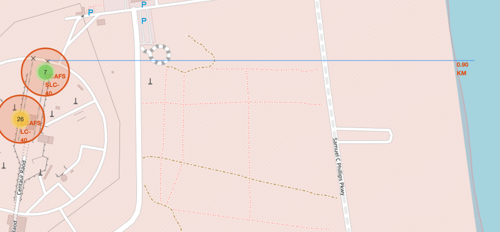

[figure not shown]

*TODO:* Similarly, you can draw a line betwee a launch site to its closest city, railway, highway, etc. You need to use `MousePosition` to find the their coordinates on the map first

A railway map symbol may look like this:

[figure not shown]

A highway map symbol may look like this:

[figure not shown]

A city map symbol may look like this:

[figure not shown]

```python
# Create a marker with distance to a closest city, railway, highway, etc.
# Draw a line between the marker to the launch site
NASA_RailRoad = [28.57437, -80.58515]
Phillips_ParkWay = [28.56267, -80.57069]
Cape_Canaveral = [28.40103, -80.6048]

disNASARR_CCAFS_LC40 = calculate_distance(launch_sites_df.loc[0, 'Lat'], launch_sites_df.loc[0, 'Long'], NASA_RailRoad[0], NASA_RailRoad[1])
disNASARR_CCAFS_SLC40 = calculate_distance(launch_sites_df.loc[1, 'Lat'], launch_sites_df.loc[1, 'Long'], NASA_RailRoad[0], NASA_RailRoad[1])

disPhiPW_CCAFS_LC40 = calculate_distance(launch_sites_df.loc[0, 'Lat'], launch_sites_df.loc[0, 'Long'], Phillips_ParkWay[0], Phillips_ParkWay[1])
disPhiPW_CCAFS_SLC40 = calculate_distance(launch_sites_df.loc[1, 'Lat'], launch_sites_df.loc[1, 'Long'], Phillips_ParkWay[0], Phillips_ParkWay[1])

disCC_CCAFS_LC40 = calculate_distance(launch_sites_df.loc[0, 'Lat'], launch_sites_df.loc[0, 'Long'], Cape_Canaveral[0], Cape_Canaveral[1])
disCC_CCAFS_SLC40 = calculate_distance(launch_sites_df.loc[1, 'Lat'], launch_sites_df.loc[1, 'Long'], Cape_Canaveral[0], Cape_Canaveral[1])
```

```python
print('The distances from Launch Site CCAFS to NASA RailRoad:', '\n')
print('CCAFS LC-40: ', disNASARR_CCAFS_LC40, ' KM')
print('CCAFS SLC-40: ', disNASARR_CCAFS_SLC40, ' KM')
```

```
The distances from Launch Site CCAFS to NASA RailRoad:

CCAFS LC-40:  1.5431968893208454  KM
CCAFS SLC-40:  1.4854576855805397  KM
```

```python
print('The distances from Launch Site CCAFS to Phillips_ParkWay:', '\n')
print('CCAFS LC-40: ', disPhiPW_CCAFS_LC40, ' KM')
print('CCAFS SLC-40: ', disPhiPW_CCAFS_SLC40, ' KM')
```

```
The distances from Launch Site CCAFS to Phillips_ParkWay:

CCAFS LC-40:  0.6525519642222193  KM
CCAFS SLC-40:  0.6017208652624306  KM
```

```python
print('The distances from Launch Site CCAFS to Cape Canaveral:', '\n')
print('CCAFS LC-40: ', disCC_CCAFS_LC40, ' KM')
print('CCAFS SLC-40: ', disCC_CCAFS_SLC40, ' KM')
```

```
The distances from Launch Site CCAFS to Cape Canaveral:

CCAFS LC-40:  18.137803735643878  KM
CCAFS SLC-40:  18.24407679652101  KM
```

```python
dismarkNRR_CCAFS_LC40 = folium.Marker(NASA_RailRoad,
                                   icon = DivIcon(icon_size = (20, 20),
                                                  icon_anchor=(0, -50),
                                                  html='<div style="font-size: 12; color:#713605;"><b>%s</b></div>' % "{:10.2f} KM".format(disNASARR_CCAFS_LC40)))

dismarkNRR_CCAFS_SLC40 = folium.Marker(NASA_RailRoad,
                                    icon = DivIcon(icon_size = (20, 20),
                                                  icon_anchor=(0, 50),
                                                  html='<div style="font-size: 12; color:#713605;"><b>%s</b></div>' % "{:10.2f} KM".format(disNASARR_CCAFS_SLC40)))

dismarkPPW_CCAFS_LC40 = folium.Marker(Phillips_ParkWay,
                                   icon = DivIcon(icon_size = (20, 20),
                                                  icon_anchor=(0, -50),
                                                  html='<div style="font-size: 12; color:#20490B;"><b>%s</b></div>' % "{:10.2f} KM".format(disPhiPW_CCAFS_LC40)))

dismarkPPW_CCAFS_SLC40 = folium.Marker(Phillips_ParkWay,
                                    icon = DivIcon(icon_size = (20, 20),
                                                  icon_anchor=(0, 50),
                                                  html='<div style="font-size: 12; color:#20490B;"><b>%s</b></div>' % "{:10.2f} KM".format(disPhiPW_CCAFS_SLC40)))

dismarkCC_CCAFS_LC40 = folium.Marker(Cape_Canaveral,
                                   icon = DivIcon(icon_size = (20, 20),
                                                  icon_anchor=(50, 0),
                                                  html='<div style="font-size: 12; color:#0E034D;"><b>%s</b></div>' % "{:10.2f} KM".format(disCC_CCAFS_LC40)))

dismarkCC_CCAFS_SLC40 = folium.Marker(Cape_Canaveral,
                                    icon = DivIcon(icon_size = (20, 20),
                                                  icon_anchor=(-50, 0),
                                                  html='<div style="font-size: 12; color:#0E034D;"><b>%s</b></div>' % "{:10.2f} KM".format(disCC_CCAFS_SLC40)))
```

```python
NRR_CCAFS_LC40 = folium.PolyLine(locations=[launch_sites_dict['CCAFS LC-40'], NASA_RailRoad], weight=2, color='orange')
NRR_CCAFS_SLC40 = folium.PolyLine(locations=[launch_sites_dict['CCAFS SLC-40'], NASA_RailRoad], weight=2, color='orange')
PPW_CCAFS_LC40 = folium.PolyLine(locations=[launch_sites_dict['CCAFS LC-40'], Phillips_ParkWay], weight=2, color='darkgreen')
PPW_CCAFS_SLC40 = folium.PolyLine(locations=[launch_sites_dict['CCAFS SLC-40'], Phillips_ParkWay], weight=2, color='darkgreen')
CC_CCAFS_LC40 = folium.PolyLine(locations=[launch_sites_dict['CCAFS LC-40'], Cape_Canaveral], weight=2, color='darkred')
CC_CCAFS_SLC40 = folium.PolyLine(locations=[launch_sites_dict['CCAFS SLC-40'], Cape_Canaveral], weight=2, color='darkred')

site_map_alt.add_child(NRR_CCAFS_LC40)
site_map_alt.add_child(NRR_CCAFS_SLC40)
site_map_alt.add_child(PPW_CCAFS_LC40)
site_map_alt.add_child(PPW_CCAFS_SLC40)
site_map_alt.add_child(CC_CCAFS_LC40)
site_map_alt.add_child(CC_CCAFS_SLC40)
site_map_alt.add_child(dismarkNRR_CCAFS_LC40)
site_map_alt.add_child(dismarkNRR_CCAFS_SLC40)
site_map_alt.add_child(dismarkPPW_CCAFS_LC40)
site_map_alt.add_child(dismarkPPW_CCAFS_SLC40)
site_map_alt.add_child(dismarkCC_CCAFS_LC40)
site_map_alt.add_child(dismarkCC_CCAFS_SLC40)

site_map_alt
```

Make this Notebook Trusted to load map: File -> Trust Notebook

[interactive chart not shown]

After you plot distance lines to the proximities, you can answer the following questions easily:

- Are launch sites in close proximity to railways?
- Are launch sites in close proximity to highways?
- Are launch sites in close proximity to coastline?
- Do launch sites keep certain distance away from cities?

Also please try to explain your findings.

# Next Steps:

Now you have discovered many interesting insights related to the launch sites' location using folium, in a very interactive way. Next, you will need to build a dashboard using Ploty Dash on detailed launch records.

## Authors

Pratiksha Verma

## Change Log

| Date (YYYY-MM-DD) | Version | Changed By | Change Description |
| --- | --- | --- | --- |
| 2022-11-09 | 1.0 | Pratiksha Verma | Converted initial version to Jupyterlite |